# Introduction to Pandas

#### Plotting with Pandas!

Pandas has a set of plotting tools built into the library. You can quickly create visualizations(especially with grouped and aggregated data which we will get to later) using pandas built in plotting functions such as:

- **`.plot`**
  - example:

    df.plot(x = 'xcolumn', y= 'ycolumn', kind = "box", xlabel= 'x value units', ylabel = 'y value units')
- **`.boxplot`**

**NOTE!** Pandas works especially well with the the seaborn plotting package. We won't cover this now because there's a whole data visualization tutorial later!

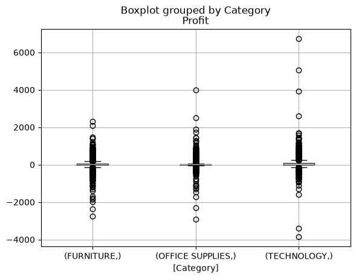

```python
# Lets create a boxplot of  profit by category

df.boxplot(column=['Profit'], by=['Category'])
```

#### get descriptive statistics

Descriptive statistic are summary statistics that quantitatively describes or summarizes features from a collection of information or dataset. This typically included things like sample size, measures of central tendency (mean, median, mode), measures of variability or dispersion (standard deviation, min, max, kurtosis, skewness)

**`.describe()`** will return descriptive statistics for all quantitative columns of a dataframe

[figure not shown]

`df.describe()`

For each numerical column the following descriptive statitsics are provided:

- count
- mean
- standard deviation
- minimum
- 25, 50 & 75th percentiles
- max

```python
df.describe()
```

|  | Category (OLD) | Quantity | Discount | Profit | Postal Code | Shipping Cost | 10/1/2014 | 7/1/2014 | 11/1/2014 | 9/1/2014 | 1/1/2014 | 12/1/2014 | 8/1/2014 | 5/1/2014 | 3/1/2014 | 4/1/2014 | 2/1/2014 | 6/1/2014 |
| --- | --- | --- | --- | --- | --- | --- | --- | --- | --- | --- | --- | --- | --- | --- | --- | --- | --- | --- |
| count | 0.0 | 17531.000000 | 17531.000000 | 17531.000000 | 3321.000000 | 17531.000000 | 1626.000000 | 1087.000000 | 2147.000000 | 2018.000000 | 918.000000 | 2153.000000 | 1675.000000 | 1284.000000 | 1068.000000 | 1051.000000 | 756.000000 | 1748.000000 |
| mean | NaN | 3.457989 | 0.143291 | 28.758540 | 56192.587775 | 26.268085 | 260.004077 | 237.999706 | 258.630194 | 238.432727 | 262.819777 | 233.694238 | 272.608921 | 224.611407 | 246.349038 | 230.991305 | 244.493857 | 229.870745 |
| std | NaN | 2.290856 | 0.211830 | 174.283412 | 31977.397359 | 56.545260 | 543.523703 | 433.300176 | 520.039000 | 463.761215 | 528.201441 | 432.184769 | 502.542821 | 396.292046 | 593.698325 | 442.449941 | 399.022820 | 423.420032 |
| min | NaN | 1.000000 | 0.000000 | -3839.990400 | 1841.000000 | 0.010000 | 0.990000 | 1.080000 | 1.197000 | 1.359000 | 2.040000 | 1.161000 | 1.584000 | 1.188000 | 0.556000 | 1.188000 | 1.788000 | 0.444000 |
| 25% | NaN | 2.000000 | 0.000000 | 0.000000 | 28110.000000 | 2.570000 | 31.491000 | 27.225000 | 30.840000 | 26.793000 | 27.412500 | 30.360000 | 36.984000 | 30.105000 | 32.202000 | 28.545000 | 35.460000 | 29.467500 |
| 50% | NaN | 3.000000 | 0.000000 | 9.200000 | 60440.000000 | 7.720000 | 87.940000 | 78.327000 | 90.936000 | 79.620000 | 83.912400 | 79.120000 | 99.870000 | 79.425000 | 83.788800 | 79.140000 | 93.765000 | 79.960000 |
| 75% | NaN | 5.000000 | 0.200000 | 36.808500 | 90032.000000 | 24.455000 | 267.678000 | 244.147500 | 269.190000 | 244.085000 | 263.491500 | 232.880000 | 284.043000 | 226.730000 | 246.533625 | 234.338000 | 275.121000 | 239.477925 |
| max | NaN | 14.000000 | 0.800000 | 6719.980800 | 99301.000000 | 867.690000 | 11199.968000 | 4001.040000 | 10499.970000 | 7958.580000 | 5443.960000 | 4864.320000 | 5211.120000 | 4298.850000 | 13999.960000 | 4799.984000 | 3425.400000 | 5486.670000 |

#### other built in summary statistic functions

Pandas also provides a large set of summary functions that can operate on different kinds of pandas objects (dataframe columns, Series, Groupby etc.)

- **`.count()`**
- **`.sum()`**
- **`.min()`**
- **`.max()`**
- **`.mean()`**
- **`.median()`**
- **`.var()`**
- **`.std()`**

These functions become especially useful in the next section where there might be some specific selection of data you want to analyze

```python
# lets do a very quick demonstration of how this works
# here we get the mean discount for the entire discount column
df["Discount"].mean()
```

```
np.float64(0.1432911984484627)
```

**STUDENT EXERCISE:**

What is the maximum value in the Shipping Cost column?

```python
df['Shipping Cost'].max()
```

```
np.float64(867.69)
```

## Data Selection, Slicing & Dicing

### Internal Links

**basic data selection & filtering**

- column selection
- 'view' of data vs a copy
- select data by labels/names
- a note on row number vs index
- select data by integer Index/position

**advanced data selection**

- select data for a given condition or threshold
- return subset of data for a given condition or threshold
- select data based on multiple conditions or thresholds

**Bonus Material** (found at end of notebook)

- multiple condition options using a list

#### Column Selection

**[column selection](https://pandas.pydata.org/docs/getting_started/intro_tutorials/03_subset_data.html#how-do-i-select-specific-columns-from-a-dataframe)**

[figure not shown]

to view a single single column

- `df['column_name']` (returns a pandas Series object, which is similar to a 1D array or list)

~ OR ~

- `df[['column_name']]` (returns a DataFrame)

multiple columns:

- `df[['column_1', 'columns_2']]`

```python
# get the Category column as a pd.series

df["Category"]
```

```
Row ID
IN-2014-23218     FURNITURE
IN-2014-24599     FURNITURE
IN-2014-24597     FURNITURE
IN-2014-27993     FURNITURE
IN-2014-28967     FURNITURE
                    ...
ZA-2014-49187    TECHNOLOGY
ZI-2014-42069    TECHNOLOGY
ZI-2014-43712    TECHNOLOGY
ZI-2014-48372    TECHNOLOGY
ZI-2014-48014    TECHNOLOGY
Name: Category, Length: 17531, dtype: str
```

```python
# get the Category and Customer ID columns

df[["Category", "Customer ID"]]
```

| Row ID | Category | Customer ID |
| --- | --- | --- |
| IN-2014-23218 | FURNITURE | AA-10375 |
| IN-2014-24599 | FURNITURE | CA-12055 |
| IN-2014-24597 | FURNITURE | CA-12055 |
| IN-2014-27993 | FURNITURE | GM-14455 |
| IN-2014-28967 | FURNITURE | VB-21745 |
| ... | ... | ... |
| ZA-2014-49187 | TECHNOLOGY | TS-11205 |
| ZI-2014-42069 | TECHNOLOGY | BS-1380 |
| ZI-2014-43712 | TECHNOLOGY | JB-6045 |
| ZI-2014-48372 | TECHNOLOGY | JC-5775 |
| ZI-2014-48014 | TECHNOLOGY | NG-8430 |

17531 rows × 2 columns

#### Views vs copies

We often want to work with only a subset of a dataframe. For that purpose, we can select only those rows or columns that we need and leave the rest.

Building off of our knowledge of views vs copies that we learned with our numpy tutorial, when we subset an array the result is not always a new array; sometimes what numpy returns is a view of the data in the original array. Since pandas Series and DataFrames are backed by numpy arrays, it will probably come as no surprise that something similar sometimes happens in pandas. Unfortunately, while this behavior is relatively straightforward in numpy, in pandas there’s just no getting around the fact that it’s a hot mess.

**The View/Copy Headache in pandas**: In numpy, the rules for when you get views and when you don’t are a little complicated, but they are consistent: certain behaviors (like simple indexing) will always return a view, and others (fancy indexing) will never return a view.

But in pandas, whether you get a view or not—and whether changes made to a view will propagate back to the original DataFrame—depends on the structure and data types in the original DataFrame

[figure not shown]

**When to create a copy using `.copy()`** **Creating copies** of dataframes can be especially useful when doing exploratory analysis on a dataframe where you want to keep the integrity of the original dataframe in case you make a mistake.

`new_df = df.copy()` makes a copy (by creating a new object) of this object’s indices and data. By default modifications to the data or indices of the copy will not be reflected in the original object but see the documentation and the parameter `deep` for more information

Note: Like all other variables, try to keep your dataframe naming descriptive and intuitive to read!(For example "new_df" would be a bad name)

[figure not shown]

#### Select rows or columns using labels

**`.loc()`** allows access to a group of rows and columns by label(s) or a boolean array.

**select rows:**

- `df.loc['index']`
  - hint: similar to column selection described above, for row selection using df.loc[ ] returns a series where df.loc[[ ]] returns a dataframe

**select row and column:**

- `df.loc['index', 'column']`

```python
# get rows where the index is IN-2014-28967

df.loc["IN-2014-28967"]
```

```
Order ID                                              IN-2014-47337
Segment                                                   Corporate
Category                                                  FURNITURE
Category (OLD)                                                  NaN
Sub-Category                                                 CHAIRS
Product Name                                 Hon Rocking Chair, Red
Product ID                                          FUR-CH-10003965
Country                                                 Afghanistan
Market                                                         APAC
Region                                                 Central Asia
Quantity                                                        7.0
Discount                                                        0.0
Profit                                                       356.58
Customer ID                                                VB-21745
Customer Name                                      Victoria Brennan
Order Priority                                                 High
Postal Code                                                     NaN
Ship Mode                                            Standard Class
Shipping Cost                                                106.41
10/1/2014                                                       NaN
7/1/2014                                                        NaN
11/1/2014                                                       NaN
9/1/2014                                                        NaN
1/1/2014                                                        NaN
12/1/2014                                                    914.34
8/1/2014                                                        NaN
5/1/2014                                                        NaN
3/1/2014                                                        NaN
4/1/2014                                                        NaN
2/1/2014                                                        NaN
6/1/2014                                                        NaN
City                                                          Kabul
State                                                         Kabul
manufacturers     [ACME Co, Buy n Large, Dunder Mifflin, LexCorp...
Name: IN-2014-28967, dtype: object
```

```python
# get index:ZI-2014-48372 and column'Country'
df.loc["ZI-2014-48372",'Country']
```

```
'Zimbabwe'
```

#### Select rows and columns by position

**[.iloc()](https://pandas.pydata.org/docs/reference/api/pandas.DataFrame.iloc.html)** allows positional selection ie row number, column number.

(Note that the same slicing notation that we saw with numpy arrays works with `iloc`.)

Example: `df.iloc([row(s) number, column(s) number])`

Examples:

```python
# get the first 9 rows and all columns
df.iloc[:9,:]
```

| Row ID | Order ID | Segment | Category | Category (OLD) | Sub-Category | Product Name | Product ID | Country | Market | Region | ... | 12/1/2014 | 8/1/2014 | 5/1/2014 | 3/1/2014 | 4/1/2014 | 2/1/2014 | 6/1/2014 | City | State | manufacturers |
| --- | --- | --- | --- | --- | --- | --- | --- | --- | --- | --- | --- | --- | --- | --- | --- | --- | --- | --- | --- | --- | --- |
| IN-2014-23218 | IN-2014-75456 | Consumer | FURNITURE | NaN | FURNISHINGS | Rubbermaid Door Stop, Erganomic | FUR-FU-10004064 | Afghanistan | APAC | Central Asia | ... | NaN | NaN | NaN | NaN | NaN | NaN | NaN | Kabul | Kabul | [Dunder Mifflin, Globex Corp, Hudsucker Indust... |
| IN-2014-24599 | IN-2014-29767 | Home Office | FURNITURE | NaN | BOOKCASES | Ikea Library with Doors, Mobile | FUR-BO-10001255 | Afghanistan | APAC | Central Asia | ... | NaN | NaN | NaN | 731.82 | NaN | NaN | NaN | Herat | Hirat | [ACME Co, Buy n Large, Dunder Mifflin, Globex ... |
| IN-2014-24597 | IN-2014-29767 | Home Office | FURNITURE | NaN | FURNISHINGS | Rubbermaid Door Stop, Erganomic | FUR-FU-10004064 | Afghanistan | APAC | Central Asia | ... | NaN | NaN | NaN | 169.68 | NaN | NaN | NaN | Herat | Hirat | [Dunder Mifflin, LexCorp, Olivander Crafts, Ro... |
| IN-2014-27993 | IN-2014-20415 | Home Office | FURNITURE | NaN | BOOKCASES | Bush Classic Bookcase, Pine | FUR-BO-10002204 | Afghanistan | APAC | Central Asia | ... | NaN | 2070.15 | NaN | NaN | NaN | NaN | NaN | Kabul | Kabul | [Dunder Mifflin, Olivander Crafts] |
| IN-2014-28967 | IN-2014-47337 | Corporate | FURNITURE | NaN | CHAIRS | Hon Rocking Chair, Red | FUR-CH-10003965 | Afghanistan | APAC | Central Asia | ... | 914.34 | NaN | NaN | NaN | NaN | NaN | NaN | Kabul | Kabul | [ACME Co, Buy n Large, Dunder Mifflin, LexCorp... |
| AG-2014-50986 | AG-2014-2760 | Consumer | FURNITURE | NaN | FURNISHINGS | Deflect-O Light Bulb, Erganomic | FUR-DEF-10002865 | Algeria | Africa | Africa | ... | NaN | NaN | NaN | NaN | NaN | NaN | 17.61 | Saida | Saida | [ACME Co, Hudsucker Industries, Wayne Enterpri... |
| AG-2014-50983 | AG-2014-2760 | Consumer | FURNITURE | NaN | CHAIRS | Novimex Rocking Chair, Black | FUR-NOV-10002453 | Algeria | Africa | Africa | ... | NaN | NaN | NaN | NaN | NaN | NaN | 516.00 | Saida | Saida | [Dunder Mifflin, Umbrella Corporation] |
| AG-2014-49384 | AG-2014-2040 | Consumer | FURNITURE | NaN | FURNISHINGS | Rubbermaid Frame, Durable | FUR-RUB-10003004 | Algeria | Africa | Africa | ... | NaN | NaN | NaN | NaN | NaN | NaN | NaN | Algiers | Alger | [Buy n Large, Hudsucker Industries, LexCorp, R... |
| AG-2014-47438 | AG-2014-2600 | Home Office | FURNITURE | NaN | BOOKCASES | Ikea 3-Shelf Cabinet, Pine | FUR-IKE-10003642 | Algeria | Africa | Africa | ... | NaN | NaN | NaN | NaN | NaN | NaN | NaN | Algiers | Alger | [Buy n Large, Dunder Mifflin, Hudsucker Indust... |

9 rows × 34 columns

```python
# get all rows and last 4 columns
df.iloc[:,-4:]
```

| Row ID | 6/1/2014 | City | State | manufacturers |
| --- | --- | --- | --- | --- |
| IN-2014-23218 | NaN | Kabul | Kabul | [Dunder Mifflin, Globex Corp, Hudsucker Indust... |
| IN-2014-24599 | NaN | Herat | Hirat | [ACME Co, Buy n Large, Dunder Mifflin, Globex ... |
| IN-2014-24597 | NaN | Herat | Hirat | [Dunder Mifflin, LexCorp, Olivander Crafts, Ro... |
| IN-2014-27993 | NaN | Kabul | Kabul | [Dunder Mifflin, Olivander Crafts] |
| IN-2014-28967 | NaN | Kabul | Kabul | [ACME Co, Buy n Large, Dunder Mifflin, LexCorp... |
| ... | ... | ... | ... | ... |
| ZA-2014-49187 | NaN | Ndola | Copperbelt | [ACME Co, Royco Waystar, Umbrella Corporation] |
| ZI-2014-42069 | NaN | Bulawayo | Bulawayo | [Dunder Mifflin] |
| ZI-2014-43712 | 77.688 | Bulawayo | Bulawayo | [ACME Co, Buy n Large, Hudsucker Industries] |
| ZI-2014-48372 | NaN | Bulawayo | Bulawayo | [ACME Co, Wayne Enterprises] |
| ZI-2014-48014 | NaN | Harare | Harare | [Dunder Mifflin, Olivander Crafts, Royco Wayst... |

17531 rows × 4 columns

#### Select data given a specific threshold or condition

You can conditionally select data using **[.loc[ ]](https://pandas.pydata.org/docs/reference/api/pandas.DataFrame.loc.html)** or **[.query()](https://pandas.pydata.org/docs/reference/api/pandas.DataFrame.query.html)** or directly on the dataframe. Each of these utilize boolean masking. `.loc`

- `df.loc[df['column'] > 7]`
- `df.loc[df['column'] == 'string']`
  - Pros: explicit, can be easier to read for those who already know python
  - cons: more verbose than query

`.query()`: This method uses boolean expressions and may be easier & more intuitive for those who know sql or other database languages.

Examples:

- `df.query('column > 7')`
- `df.query('column == string')`
  - Pros: can be easier for those who know sql or other database languages, less verbose
  - cons: can be difficult for those that donn't know sql, doesn't hand column names that contain spaces very well

```python
# use .loc to select where Profit > 500
df.loc[df['Profit'] > 500]
```

| Row ID | Order ID | Segment | Category | Category (OLD) | Sub-Category | Product Name | Product ID | Country | Market | Region | ... | 12/1/2014 | 8/1/2014 | 5/1/2014 | 3/1/2014 | 4/1/2014 | 2/1/2014 | 6/1/2014 | City | State | manufacturers |
| --- | --- | --- | --- | --- | --- | --- | --- | --- | --- | --- | --- | --- | --- | --- | --- | --- | --- | --- | --- | --- | --- |
| IN-2014-27993 | IN-2014-20415 | Home Office | FURNITURE | NaN | BOOKCASES | Bush Classic Bookcase, Pine | FUR-BO-10002204 | Afghanistan | APAC | Central Asia | ... | NaN | 2070.15 | NaN | NaN | NaN | NaN | NaN | Kabul | Kabul | [Dunder Mifflin, Olivander Crafts] |
| AO-2014-44396 | AO-2014-2270 | Consumer | FURNITURE | NaN | TABLES | Chromcraft Round Table, Adjustable Height | FUR-CHR-10002278 | Angola | Africa | Africa | ... | NaN | NaN | 1877.16 | NaN | NaN | NaN | NaN | Luanda | Luanda | [Dunder Mifflin, Globex Corp, LexCorp, Royco W... |
| IN-2014-24624 | IN-2014-23880 | Consumer | FURNITURE | NaN | BOOKCASES | Sauder Classic Bookcase, Traditional | FUR-BO-10004852 | Australia | APAC | Oceania | ... | NaN | NaN | NaN | NaN | NaN | NaN | 3139.128 | Mandurah | Western Australia | [Buy n Large, Globex Corp, LexCorp, Umbrella C... |
| IN-2014-31153 | IN-2014-80286 | Consumer | FURNITURE | NaN | CHAIRS | Harbour Creations Executive Leather Armchair, ... | FUR-CH-10000051 | Australia | APAC | Oceania | ... | NaN | NaN | NaN | NaN | NaN | NaN | NaN | Wollongong | New South Wales | [Globex Corp, LexCorp, Royco Waystar, Umbrella... |
| ID-2014-21496 | ID-2014-35892 | Consumer | FURNITURE | NaN | CHAIRS | SAFCO Executive Leather Armchair, Set of Two | FUR-CH-10003597 | Australia | APAC | Oceania | ... | NaN | NaN | NaN | NaN | NaN | NaN | NaN | Brisbane | Queensland | [ACME Co, Buy n Large, Dunder Mifflin, Globex ... |
| ... | ... | ... | ... | ... | ... | ... | ... | ... | ... | ... | ... | ... | ... | ... | ... | ... | ... | ... | ... | ... | ... |
| CA-2014-33921 | CA-2014-127180 | Home Office | TECHNOLOGY | NaN | PHONES | Polycom CX600 IP Phone VoIP phone | TEC-PH-10001494 | United States | US | East | ... | NaN | NaN | NaN | NaN | NaN | NaN | NaN | New York City | New York | [Buy n Large, Dunder Mifflin, Hudsucker Indust... |
| CA-2014-33920 | CA-2014-127180 | Home Office | TECHNOLOGY | NaN | COPIERS | Canon imageCLASS 2200 Advanced Copier | TEC-CO-10004722 | United States | US | East | ... | NaN | NaN | NaN | NaN | NaN | NaN | NaN | New York City | New York | [Globex Corp] |
| CA-2014-36178 | CA-2014-143567 | Corporate | TECHNOLOGY | NaN | ACCESSORIES | Logitech diNovo Edge Keyboard | TEC-AC-10004145 | United States | US | South | ... | NaN | NaN | NaN | NaN | NaN | NaN | NaN | Henderson | Kentucky | [Dunder Mifflin, Globex Corp, Hudsucker Indust... |
| CA-2014-37637 | CA-2014-143112 | Corporate | TECHNOLOGY | NaN | MACHINES | 3D Systems Cube Printer, 2nd Generation, Magenta | TEC-MA-10001047 | United States | US | East | ... | NaN | NaN | NaN | NaN | NaN | NaN | NaN | New York City | New York | [Buy n Large, Hudsucker Industries, LexCorp, O... |
| CA-2014-38429 | CA-2014-141439 | Home Office | TECHNOLOGY | NaN | PHONES | Samsung Galaxy S4 Mini | TEC-PH-10002624 | United States | US | Central | ... | NaN | NaN | NaN | NaN | NaN | NaN | NaN | Richmond | Indiana | [Hudsucker Industries, LexCorp, Olivander Craf... |

231 rows × 34 columns

#### Return a subset of data given a specific threshold or condition

You can also return specific columns after doing conditional selection data using **[`.loc`](https://pandas.pydata.org/docs/reference/api/pandas.DataFrame.loc.html)**.

single return column:

- `df.loc[df['selection_column'] > 7, 'return_column']`

multiple return columns (provide columns as a list):

- `df.loc[df['selection_column'] > 7, ['return_column1', 'return_column2']]`

```python
# get the Category and Sub-Category where profit is above 500

df.loc[df["Profit"] > 500, ["Category", "Sub-Category"]]
```

| Row ID | Category | Sub-Category |
| --- | --- | --- |
| IN-2014-27993 | FURNITURE | BOOKCASES |
| AO-2014-44396 | FURNITURE | TABLES |
| IN-2014-24624 | FURNITURE | BOOKCASES |
| IN-2014-31153 | FURNITURE | CHAIRS |
| ID-2014-21496 | FURNITURE | CHAIRS |
| ... | ... | ... |
| CA-2014-33921 | TECHNOLOGY | PHONES |
| CA-2014-33920 | TECHNOLOGY | COPIERS |
| CA-2014-36178 | TECHNOLOGY | ACCESSORIES |
| CA-2014-37637 | TECHNOLOGY | MACHINES |
| CA-2014-38429 | TECHNOLOGY | PHONES |

231 rows × 2 columns

**Multiple condition selection**

You may wish to select rows or columns where multiple conditions are met. You can combine conditions with `.loc` and like in numpy you will utilize `&` and `|`

example: `df.loc[(df['column1']=='string') & (df['column2'] > threshold)]`

```python
# return all entries where Profit is greater than 900 and the Sub-Category is "Bookcases"
# the & means both conditions must be met

df.loc[(df['Sub-Category']=="BOOKCASES") & (df['Profit'] >900)]
```

| Row ID | Order ID | Segment | Category | Category (OLD) | Sub-Category | Product Name | Product ID | Country | Market | Region | ... | 12/1/2014 | 8/1/2014 | 5/1/2014 | 3/1/2014 | 4/1/2014 | 2/1/2014 | 6/1/2014 | City | State | manufacturers |
| --- | --- | --- | --- | --- | --- | --- | --- | --- | --- | --- | --- | --- | --- | --- | --- | --- | --- | --- | --- | --- | --- |
| IN-2014-24624 | IN-2014-23880 | Consumer | FURNITURE | NaN | BOOKCASES | Sauder Classic Bookcase, Traditional | FUR-BO-10004852 | Australia | APAC | Oceania | ... | NaN | NaN | NaN | NaN | NaN | NaN | 3139.128 | Mandurah | Western Australia | [Buy n Large, Globex Corp, LexCorp, Umbrella C... |
| IN-2014-21263 | IN-2014-56206 | Consumer | FURNITURE | NaN | BOOKCASES | Sauder Classic Bookcase, Metal | FUR-BO-10001471 | Australia | APAC | Oceania | ... | NaN | NaN | NaN | NaN | NaN | NaN | 5486.670 | Sydney | New South Wales | [ACME Co, Buy n Large, Hudsucker Industries, U... |
| IN-2014-24037 | IN-2014-17930 | Consumer | FURNITURE | NaN | BOOKCASES | Sauder Classic Bookcase, Metal | FUR-BO-10001471 | China | APAC | North Asia | ... | NaN | NaN | NaN | NaN | NaN | NaN | NaN | Qingdao | Shandong | [ACME Co, Globex Corp, Hudsucker Industries, O... |
| IN-2014-28056 | IN-2014-66573 | Consumer | FURNITURE | NaN | BOOKCASES | Bush Classic Bookcase, Mobile | FUR-BO-10004665 | China | APAC | North Asia | ... | NaN | NaN | NaN | NaN | NaN | NaN | NaN | Beijing | Beijing | [ACME Co, Buy n Large, Olivander Crafts, Umbre... |
| MX-2014-4452 | MX-2014-157077 | Consumer | FURNITURE | NaN | BOOKCASES | Dania Classic Bookcase, Traditional | FUR-BO-10002300 | Cuba | LATAM | Caribbean | ... | NaN | NaN | NaN | NaN | NaN | NaN | NaN | Camagüey | Camagüey | [ACME Co, Buy n Large, Globex Corp, Royco Ways... |
| IN-2014-25795 | IN-2014-76016 | Corporate | FURNITURE | NaN | BOOKCASES | Sauder Classic Bookcase, Traditional | FUR-BO-10004852 | India | APAC | Central Asia | ... | NaN | NaN | NaN | NaN | NaN | NaN | NaN | Thiruvananthapuram | Kerala | [Buy n Large, Hudsucker Industries, Umbrella C... |
| IT-2014-16653 | IT-2014-4540740 | Consumer | FURNITURE | NaN | BOOKCASES | Safco Classic Bookcase, Metal | FUR-BO-10004999 | Spain | EU | South | ... | 2188.05 | NaN | NaN | NaN | NaN | NaN | NaN | Seville | Andalusía | [Globex Corp, Hudsucker Industries, Olivander ... |
| ES-2014-12449 | ES-2014-4957212 | Consumer | FURNITURE | NaN | BOOKCASES | Bush Classic Bookcase, Pine | FUR-BO-10004709 | United Kingdom | EU | North | ... | NaN | NaN | NaN | NaN | NaN | NaN | NaN | Burnley | England | [Buy n Large, Globex Corp, LexCorp, Olivander ... |
| ZA-2014-42448 | ZA-2014-7540 | Consumer | FURNITURE | NaN | BOOKCASES | Ikea Library with Doors, Traditional | FUR-IKE-10002894 | Zambia | Africa | Africa | ... | NaN | NaN | NaN | NaN | NaN | NaN | NaN | Lusaka | Lusaka | [ACME Co, Royco Waystar, Umbrella Corporation,... |

9 rows × 34 columns

```python
# return all entries where the Country is "Australia" or the Country is "Zambia"
# the | means at least one condition must be met

df.loc[(df['Country']=="Australia") | (df['Country']=="Zambia")]
```

| Row ID | Order ID | Segment | Category | Category (OLD) | Sub-Category | Product Name | Product ID | Country | Market | Region | ... | 12/1/2014 | 8/1/2014 | 5/1/2014 | 3/1/2014 | 4/1/2014 | 2/1/2014 | 6/1/2014 | City | State | manufacturers |
| --- | --- | --- | --- | --- | --- | --- | --- | --- | --- | --- | --- | --- | --- | --- | --- | --- | --- | --- | --- | --- | --- |
| ID-2014-25801 | ID-2014-42388 | Consumer | FURNITURE | NaN | FURNISHINGS | Deflect-O Frame, Duo Pack | FUR-FU-10004780 | Australia | APAC | Oceania | ... | NaN | 99.09 | NaN | NaN | NaN | NaN | NaN | Wollongong | New South Wales | [Hudsucker Industries] |
| IN-2014-21802 | IN-2014-25644 | Consumer | FURNITURE | NaN | BOOKCASES | Bush Corner Shelving, Metal | FUR-BO-10004230 | Australia | APAC | Oceania | ... | 444.42 | NaN | NaN | NaN | NaN | NaN | NaN | Tamworth | New South Wales | [Hudsucker Industries, LexCorp] |
| IN-2014-22521 | IN-2014-10090 | Consumer | FURNITURE | NaN | CHAIRS | Harbour Creations Steel Folding Chair, Red | FUR-CH-10001204 | Australia | APAC | Oceania | ... | NaN | NaN | NaN | NaN | 88.101 | NaN | NaN | Sydney | New South Wales | [Buy n Large, Dunder Mifflin, Globex Corp, Oli... |
| IN-2014-26860 | IN-2014-64396 | Home Office | FURNITURE | NaN | FURNISHINGS | Deflect-O Stacking Tray, Black | FUR-FU-10001129 | Australia | APAC | Oceania | ... | NaN | NaN | NaN | NaN | NaN | NaN | 91.26 | Bundaberg | Queensland | [ACME Co, Buy n Large, Dunder Mifflin, LexCorp... |
| ID-2014-30742 | ID-2014-84164 | Home Office | FURNITURE | NaN | FURNISHINGS | Tenex Photo Frame, Duo Pack | FUR-FU-10000507 | Australia | APAC | Oceania | ... | NaN | NaN | NaN | 31.14 | NaN | NaN | NaN | Cairns | Queensland | [ACME Co, Dunder Mifflin, Olivander Crafts] |
| ... | ... | ... | ... | ... | ... | ... | ... | ... | ... | ... | ... | ... | ... | ... | ... | ... | ... | ... | ... | ... | ... |
| ZA-2014-41769 | ZA-2014-1370 | Consumer | TECHNOLOGY | NaN | COPIERS | Brother Personal Copier, Color | TEC-BRO-10003986 | Zambia | Africa | Africa | ... | NaN | NaN | NaN | NaN | NaN | NaN | NaN | Chingola | Copperbelt | [ACME Co, Hudsucker Industries, Olivander Craf... |
| ZA-2014-45397 | ZA-2014-8330 | Corporate | TECHNOLOGY | NaN | PHONES | Cisco Headset, VoIP | TEC-CIS-10003439 | Zambia | Africa | Africa | ... | NaN | 88.53 | NaN | NaN | NaN | NaN | NaN | Lusaka | Lusaka | [Buy n Large, Olivander Crafts, Umbrella Corpo... |
| ZA-2014-50068 | ZA-2014-6660 | Home Office | TECHNOLOGY | NaN | COPIERS | Brother Fax and Copier, High-Speed | TEC-BRO-10003401 | Zambia | Africa | Africa | ... | NaN | NaN | NaN | NaN | NaN | 189.69 | NaN | Lusaka | Lusaka | [Buy n Large, LexCorp, Olivander Crafts, Umbre... |
| ZA-2014-50069 | ZA-2014-6660 | Home Office | TECHNOLOGY | NaN | COPIERS | Hewlett Fax Machine, High-Speed | TEC-HEW-10002304 | Zambia | Africa | Africa | ... | NaN | NaN | NaN | NaN | NaN | 318.12 | NaN | Lusaka | Lusaka | [Buy n Large, Globex Corp, Hudsucker Industrie... |
| ZA-2014-49187 | ZA-2014-9750 | Corporate | TECHNOLOGY | NaN | ACCESSORIES | Memorex Router, USB | TEC-MEM-10002202 | Zambia | Africa | Africa | ... | NaN | NaN | NaN | NaN | NaN | 246.42 | NaN | Ndola | Copperbelt | [ACME Co, Royco Waystar, Umbrella Corporation] |

1023 rows × 34 columns

**STUDENT EXERCISES:**

1. Select Row ID "AG-2014-50983" and all columns
2. Get the mean profit when the Category is furniture
3. How many entries in the dataframe are there where "Profit" is negative and "Market" is 'EU'

```python
# Answer 1:
df.loc["AG-2014-50983"]
```

```
Order ID                                    AG-2014-2760
Segment                                         Consumer
Category                                       FURNITURE
Category (OLD)                                       NaN
Sub-Category                                      CHAIRS
Product Name                Novimex Rocking Chair, Black
Product ID                              FUR-NOV-10002453
Country                                          Algeria
Market                                            Africa
Region                                            Africa
Quantity                                             4.0
Discount                                             0.0
Profit                                             61.92
Customer ID                                      CL-2565
Customer Name                                Clay Ludtke
Order Priority                                      High
Postal Code                                      41244.0
Ship Mode                                 Standard Class
Shipping Cost                                      46.75
10/1/2014                                            NaN
7/1/2014                                             NaN
11/1/2014                                            NaN
9/1/2014                                             NaN
1/1/2014                                             NaN
12/1/2014                                            NaN
8/1/2014                                             NaN
5/1/2014                                             NaN
3/1/2014                                             NaN
4/1/2014                                             NaN
2/1/2014                                             NaN
6/1/2014                                           516.0
City                                               Saida
State                                              Saida
manufacturers     [Dunder Mifflin, Umbrella Corporation]
Name: AG-2014-50983, dtype: object
```

```python
# Answer 2 with loc:
df.loc[df['Category']=='FURNITURE', 'Profit'].mean()
```

```
np.float64(26.68421359426352)
```

```python
# Answer 3
# Return the dataframe where "Profit" is negative and "Market" is 'EU'

# using .loc:
len(df.loc[(df['Profit'] < 0) & (df['Market'] == 'EU')])

# using .query:
len(df.query('Profit < 0 & Market == "EU"'))
```

```
768
```

## Data Manipulations

### Internal links

- adjust column type
- create new columns
  - .apply()
- drop unneccesary or redundant columns
- drop nan, NULL entries
- sort the whole dataframe based on one column's values

#### change column data type

After examining your dataframe you may find that there are certain columns whose data types do not match your assumptions or whose data types could inhibit analysis. For example, if you have a column that contains numbers, but the data type is string- you would not actually be able to do numeric operations on it. You can cast the data to a different datatype using **[.astype()](https://pandas.pydata.org/docs/reference/api/pandas.DataFrame.astype.html)**.

to cast a column to a new data type: `df['column_1'] = df['column_1'].astype(new type)`

remember some of the possible datatypes are:

- int
- float64
- bool
- string

```python
# we know that in our dataframe quantity should be an integer
# but right now it's a float- lets change that using .astype()
# then we can check the type after

# change the type to an int
df['Quantity'] = df['Quantity'].astype(int)

# check the data type
df["Quantity"]
```

```
Row ID
IN-2014-23218    2
IN-2014-24599    2
IN-2014-24597    4
IN-2014-27993    5
IN-2014-28967    7
                ..
ZA-2014-49187    1
ZI-2014-42069    1
ZI-2014-43712    1
ZI-2014-48372    2
ZI-2014-48014    1
Name: Quantity, Length: 17531, dtype: int64
```

#### Add new columns

Frequently you'll want to add **[new columns](https://pandas.pydata.org/docs/getting_started/intro_tutorials/05_add_columns.html)**. There are multiple ways to do this!

[figure not shown]

to add already computed data: * `df['new_column_name'] = already_computed_data`

You can also calculate new columns based on currently existing columns:

- `df['AB_SUM'] = df['A'] + df['B']`
- `df['Volume'] = df['Length'] * df['Height'] * df['Depth']`

note: newly created columns are always added to the end of the dataframe

```python
# lets create a "Profit Per Unit" column by diving profit by quantity
df['Profit Per Unit'] = df['Profit'] / df['Quantity']

# now lets view the results
df[["Profit", "Quantity", "Profit Per Unit"]]
```

| Row ID | Profit | Quantity | Profit Per Unit |
| --- | --- | --- | --- |
| IN-2014-23218 | 39.840 | 2 | 19.920 |
| IN-2014-24599 | 102.420 | 2 | 51.210 |
| IN-2014-24597 | 79.680 | 4 | 19.920 |
| IN-2014-27993 | 848.700 | 5 | 169.740 |
| IN-2014-28967 | 356.580 | 7 | 50.940 |
| ... | ... | ... | ... |
| ZA-2014-49187 | 19.710 | 1 | 19.710 |
| ZI-2014-42069 | -20.799 | 1 | -20.799 |
| ZI-2014-43712 | -59.562 | 1 | -59.562 |
| ZI-2014-48372 | -93.180 | 2 | -46.590 |
| ZI-2014-48014 | -20.298 | 1 | -20.298 |

17531 rows × 3 columns

#### .apply()

**[.apply()](https://pandas.pydata.org/docs/reference/api/pandas.DataFrame.apply.html)** is a fairly powerful tool that can do many things. In this context we will use it to create new columns using functions from other packages or functions you've created.

- `df['new_column_name'] = df[column(s) of interest].apply(function)`
- `df['A_sqrt'] = df['A'].apply(np.sqrt)`
- `df['A_adjusted'] = df['A'].apply(your_function)`

```python
# lets practice by making a function that will fix the capitolization of the
# Category" column and then applying it

def capitalize_first_letter(string):
    all_lower = string.lower()
    cap_first = all_lower.capitalize()
    return cap_first

df['Category'] = df['Category'].apply(capitalize_first_letter)

# view the results
df[['Category']]
```

| Row ID | Category |
| --- | --- |
| IN-2014-23218 | Furniture |
| IN-2014-24599 | Furniture |
| IN-2014-24597 | Furniture |
| IN-2014-27993 | Furniture |
| IN-2014-28967 | Furniture |
| ... | ... |
| ZA-2014-49187 | Technology |
| ZI-2014-42069 | Technology |
| ZI-2014-43712 | Technology |
| ZI-2014-48372 | Technology |
| ZI-2014-48014 | Technology |

17531 rows × 1 columns

**STUDENT EXERCISES:**

1. In these code examples, what do you think the `axis` argument is doing? What kind of output do you think will be returned? for each?
- `df[['A', 'B']].apply(np.mean, axis = 0)`
- `df[['A', 'B']].apply(np.mean, axis = 1)`
2. Which axis setting is the default? (hint- check the documentation)

```python
### Your answer here:
# Solution 1:
# 0 or 'index': apply function to each column.
# 1 or 'columns': apply function to each row.
```

```python
# code to see the output differences
df[["Quantity", "Profit Per Unit"]].apply(np.sum, axis = 0)
```

```
Quantity            60622.00000
Profit Per Unit    144656.52516
dtype: float64
```

```python
# code to see the output differences
df[["Quantity", "Profit Per Unit"]].apply(np.sum, axis = 1)
```

```
Row ID
IN-2014-23218     21.920
IN-2014-24599     53.210
IN-2014-24597     23.920
IN-2014-27993    174.740
IN-2014-28967     57.940
                  ...
ZA-2014-49187     20.710
ZI-2014-42069    -19.799
ZI-2014-43712    -58.562
ZI-2014-48372    -44.590
ZI-2014-48014    -19.298
Length: 17531, dtype: float64
```

```python
### Your answer here:
# Solution 2:
# 0 is the default- meaning it will automatically apply to columns.
```

#### lambda functions

**[lambda](https://www.geeksforgeeks.org/python-lambda-anonymous-functions-filter-map-reduce/#)** is a built in python function that is often used with .apply() for pandas data manipulations.

Python Lambda Functions are anonymous function means that the function is without a name. As we already know that the def keyword is used to define a normal function in Python. Similarly, the lambda keyword is used to define an anonymous function in Python.

- syntactically restricted to a single expression
- Good for performing short operations/data manipulations
- generally reduce the readability of code
- `lambda input_data: data manipulation`
- `lambda string: string.lower().capitalize()`

Defined function:

```
def cube(num):
return num * num * num
```

Lambda equivalent:

`lambda num: num * num * num`

**STUDENT EXERCISES:**

1. create a lambda function that adds 100 to an input value

```python
# solution 1
plus_100 = lambda num: num + 100
```

#### using .apply(lambda)

**[.apply(lambda)](https://www.geeksforgeeks.org/applying-lambda-functions-to-pandas-dataframe/#)** is frequently used for row-wise operations, though there are several ways it can be utilized.

In this setting lambda is the function that will be used by .apply

- `data.apply(lambda input: manipulation)`

column-wise generic example:

- `df['text column'].apply(lambda string: string.lower().capitalize())`

row-wise generic example:

- `df.apply(lambda row: df['column_A']*df['column_B'], axis = 1)`

```python
# lets use .apply(lambda) to create a new column that will count the number of manufactuters
# from the 'manufacturers' column array

df['manufacturers_count'] = df.apply(lambda row : len(row['manufacturers']), axis = 1)
```

**STUDENT EXERCISES:**

1. use `.apply(lambda )` to apply the `capitalize_first_letter function` to the 'Sub-Category' column

```python
# solution 1
df['Sub-Category'] = df['Sub-Category'].apply(lambda string: capitalize_first_letter(string))
```

#### Drop specific columns & rows using

You can easily drop rows or columns using **`.drop()`**

There are many reasons you may wish to drop columns from your dataframe. Here are a few examples:

- irrlevant to the analysis you are going to do
- out of date
- redundant information
- non-analyzable due to high rates of Nan or empty entries

drop columns:

- `df = df.drop(columns=['column1', 'columns2'])`
- `df = df.drop('column_name',axis=1)`

drop rows:

- `df = df.drop(index=('index1_string, 'index2_string'))`
- `df = df.drop([row, row])`

```python
# Lets drop the 'Category (OLD)'column

df.drop(columns=['Category (OLD)'], inplace=True)

# check the results in the dataframe columns list
df.columns
```

```
Index(['Order ID', 'Segment', 'Category', 'Sub-Category', 'Product Name',
       'Product ID', 'Country', 'Market', 'Region', 'Quantity', 'Discount',
       'Profit', 'Customer ID', 'Customer Name', 'Order Priority',
       'Postal Code', 'Ship Mode', 'Shipping Cost', '10/1/2014', '7/1/2014',
       '11/1/2014', '9/1/2014', '1/1/2014', '12/1/2014', '8/1/2014',
       '5/1/2014', '3/1/2014', '4/1/2014', '2/1/2014', '6/1/2014', 'City',
       'State', 'manufacturers', 'Profit Per Unit', 'manufacturers_count'],
      dtype='str')
```

#### Modifying data inplace

**`inplace`** is a parameter accepted by a number of pandas methods which affects the behaviour of how the method runs. Some examples of where you might commonly see this keyword are the methods(non-exhaustive):

- `.drop()`
- `.fillna()`
- `.replace()`
- `.rename()`

Using the `inplace=True` keyword in a pandas method changes the default behaviour such that the operation on the dataframe doesn’t return anything, it instead ‘modifies the underlying data’. It mutates the actual object which you apply it to.

#### remove rows with missing values

For columns of particular importance may wish to exclude rows that have missing values to do this we use **`.dropna()`**

example: `df.dropna(subset=['column'], inplace=bool)`

```python
# we will also have an example of this in the next section!
```

#### Sort the dataframe based on column values

**`.sort_values()`** to sort your dataframe by the the values of a particular column or columns.

`df.sort_values(by=['column1', 'column2'], ascending = boolean, inplace= boolean)`

pro-tip: Sorting the values of your dataframe before plotting creates more interpretable plots.

```python
# Lets sort our USA_df by 'Segment', 'Category' and 'Sub-Category'
# we will leave the underlying data unchanged by setting inpace to False

df.sort_values(by = ['Segment', 'Category', 'Sub-Category'], inplace = False)
```

| Row ID | Order ID | Segment | Category | Sub-Category | Product Name | Product ID | Country | Market | Region | Quantity | ... | 5/1/2014 | 3/1/2014 | 4/1/2014 | 2/1/2014 | 6/1/2014 | City | State | manufacturers | Profit Per Unit | manufacturers_count |
| --- | --- | --- | --- | --- | --- | --- | --- | --- | --- | --- | --- | --- | --- | --- | --- | --- | --- | --- | --- | --- | --- |
| AG-2014-46003 | AG-2014-8600 | Consumer | Furniture | Bookcases | Sauder Classic Bookcase, Pine | FUR-SAU-10002255 | Algeria | Africa | Africa | 2 | ... | NaN | NaN | NaN | NaN | NaN | Batna | Batna | [ACME Co, Globex Corp, Umbrella Corporation] | 74.3400 | 3 |
| AO-2014-45199 | AO-2014-9370 | Consumer | Furniture | Bookcases | Bush Classic Bookcase, Pine | FUR-BUS-10001243 | Angola | Africa | Africa | 2 | ... | 828.06 | NaN | NaN | NaN | NaN | Luanda | Luanda | [ACME Co, Buy n Large, Globex Corp, Hudsucker ... | 202.8600 | 7 |
| US-2014-6344 | US-2014-165512 | Consumer | Furniture | Bookcases | Bush Library with Doors, Metal | FUR-BO-10002968 | Argentina | LATAM | South | 2 | ... | NaN | 291.0240 | NaN | NaN | NaN | Buenos Aires | Buenos Aires | [Dunder Mifflin, Globex Corp, Hudsucker Indust... | -58.2080 | 6 |
| US-2014-1158 | US-2014-107664 | Consumer | Furniture | Bookcases | Ikea Floating Shelf Set, Traditional | FUR-BO-10001585 | Argentina | LATAM | South | 4 | ... | NaN | NaN | NaN | NaN | NaN | La Plata | Provincia de Buenos Aires | [Dunder Mifflin, Hudsucker Industries, Royco W... | -13.6440 | 3 |
| IN-2014-21802 | IN-2014-25644 | Consumer | Furniture | Bookcases | Bush Corner Shelving, Metal | FUR-BO-10004230 | Australia | APAC | Oceania | 4 | ... | NaN | NaN | NaN | NaN | NaN | Tamworth | New South Wales | [Hudsucker Industries, LexCorp] | 38.2650 | 2 |
| ... | ... | ... | ... | ... | ... | ... | ... | ... | ... | ... | ... | ... | ... | ... | ... | ... | ... | ... | ... | ... | ... |
| US-2014-40156 | US-2014-114356 | Home Office | Technology | Phones | Plantronics Encore H101 Dual Earpieces Headset | TEC-PH-10003171 | United States | US | South | 1 | ... | NaN | NaN | NaN | NaN | NaN | Charlotte | North Carolina | [ACME Co, Buy n Large, LexCorp, Olivander Craf... | 3.5960 | 6 |
| US-2014-33227 | US-2014-101539 | Home Office | Technology | Phones | Mitel MiVoice 5330e IP Phone | TEC-PH-10004165 | United States | US | West | 3 | ... | NaN | 659.9760 | NaN | NaN | NaN | Seattle | Washington | [ACME Co, Royco Waystar, Umbrella Corporation,... | 16.4994 | 4 |
| CA-2014-36882 | CA-2014-105333 | Home Office | Technology | Phones | Panasonic Business Telephones KX-T7736 | TEC-PH-10001468 | United States | US | East | 3 | ... | NaN | NaN | NaN | NaN | NaN | New York City | New York | [LexCorp, Umbrella Corporation, Wayne Enterpri... | 54.6060 | 3 |
| ID-2014-26472 | ID-2014-41597 | Home Office | Technology | Phones | Nokia Speaker Phone, Cordless | TEC-PH-10001535 | Vietnam | APAC | Southeast Asia | 2 | ... | NaN | 209.1600 | NaN | NaN | NaN | Ho Chi Minh City | Ho Chí Minh City | [ACME Co, Hudsucker Industries, Umbrella Corpo... | 5.0400 | 3 |
| ID-2014-26474 | ID-2014-41597 | Home Office | Technology | Phones | Samsung Signal Booster, with Caller ID | TEC-PH-10003239 | Vietnam | APAC | Southeast Asia | 7 | ... | NaN | 793.5879 | NaN | NaN | NaN | Ho Chi Minh City | Ho Chí Minh City | [Globex Corp, Hudsucker Industries, LexCorp, O... | 34.1397 | 5 |

17531 rows × 35 columns

**STUDENT EXERCISES:**

2. sort the table by profit per unit

```python
# answer 2
df.sort_values(by = 'Profit Per Unit', inplace = False)
```

| Row ID | Order ID | Segment | Category | Sub-Category | Product Name | Product ID | Country | Market | Region | Quantity | ... | 5/1/2014 | 3/1/2014 | 4/1/2014 | 2/1/2014 | 6/1/2014 | City | State | manufacturers | Profit Per Unit | manufacturers_count |
| --- | --- | --- | --- | --- | --- | --- | --- | --- | --- | --- | --- | --- | --- | --- | --- | --- | --- | --- | --- | --- | --- |
| US-2014-31980 | US-2014-168116 | Corporate | Technology | Machines | Cubify CubeX 3D Printer Triple Head Print | TEC-MA-10004125 | United States | US | South | 4 | ... | NaN | NaN | NaN | NaN | NaN | Burlington | North Carolina | [ACME Co, Buy n Large, Dunder Mifflin, Globex ... | -959.9976 | 7 |
| CA-2014-34308 | CA-2014-134845 | Home Office | Technology | Machines | Lexmark MX611dhe Monochrome Laser Printer | TEC-MA-10000822 | United States | US | West | 5 | ... | NaN | NaN | 2549.985 | NaN | NaN | Louisville | Colorado | [Hudsucker Industries, LexCorp, Olivander Craf... | -679.9960 | 4 |
| US-2014-36288 | US-2014-122714 | Corporate | Office supplies | Binders | Ibico EPK-21 Electric Binding System | OFF-BI-10001120 | United States | US | Central | 5 | ... | NaN | NaN | NaN | NaN | NaN | Chicago | Illinois | [Umbrella Corporation] | -585.8969 | 1 |
| CA-2014-34143 | CA-2014-152093 | Home Office | Office supplies | Binders | Fellowes PB500 Electric Punch Plastic Comb Bin... | OFF-BI-10003527 | United States | US | Central | 3 | ... | NaN | NaN | NaN | NaN | NaN | Chicago | Illinois | [Buy n Large, Dunder Mifflin, LexCorp] | -381.2970 | 3 |
| CA-2014-36607 | CA-2014-131254 | Consumer | Office supplies | Binders | Fellowes PB500 Electric Punch Plastic Comb Bin... | OFF-BI-10003527 | United States | US | Central | 6 | ... | NaN | NaN | NaN | NaN | NaN | Houston | Texas | [Buy n Large, LexCorp] | -381.2970 | 2 |
| ... | ... | ... | ... | ... | ... | ... | ... | ... | ... | ... | ... | ... | ... | ... | ... | ... | ... | ... | ... | ... | ... |
| SF-2014-48905 | SF-2014-4490 | Consumer | Furniture | Tables | Bevis Conference Table, Rectangular | FUR-BEV-10004805 | South Africa | Africa | Africa | 2 | ... | NaN | NaN | NaN | NaN | NaN | George | Western Cape | [Dunder Mifflin] | 442.2300 | 1 |
| CA-2014-37817 | CA-2014-138289 | Consumer | Office supplies | Binders | GBC DocuBind P400 Electric Binding System | OFF-BI-10004995 | United States | US | Central | 4 | ... | NaN | NaN | NaN | NaN | NaN | Jackson | Michigan | [Buy n Large, Hudsucker Industries, LexCorp, O... | 626.0554 | 6 |
| CA-2014-33920 | CA-2014-127180 | Home Office | Technology | Copiers | Canon imageCLASS 2200 Advanced Copier | TEC-CO-10004722 | United States | US | East | 4 | ... | NaN | NaN | NaN | NaN | NaN | New York City | New York | [Globex Corp] | 979.9972 | 1 |
| CA-2014-35487 | CA-2014-166709 | Consumer | Technology | Copiers | Canon imageCLASS 2200 Advanced Copier | TEC-CO-10004722 | United States | US | East | 3 | ... | NaN | NaN | NaN | NaN | NaN | Newark | Delaware | [Buy n Large, Dunder Mifflin, Globex Corp, Hud... | 1679.9952 | 8 |
| CA-2014-39450 | CA-2014-140151 | Consumer | Technology | Copiers | Canon imageCLASS 2200 Advanced Copier | TEC-CO-10004722 | United States | US | West | 4 | ... | NaN | 13999.96 | NaN | NaN | NaN | Seattle | Washington | [ACME Co, Royco Waystar] | 1679.9952 | 2 |

17531 rows × 35 columns

## Table transformation, aggregation & Plotting

### Internal links

NOTE: while this tutorial uses pandas built in plotting functions there are many better packages for plotting, the [Seaborn](https://seaborn.pydata.org/) package workes especially well with pandas dataframe and other tabular style data

```python
# lets create a new dataframe for this next set of examples
# use .loc[] to select the united states as the country and .copy() to ensure
# it's a new object and not altering our base dataframe

USA_df = df.loc[df["Country"]=="United States"].copy()
```

#### Resetting the index

In many of the table transformations, the process of transforming the data changes the index. If we wish to retain the index row we will want to reset the index before we do these transformations so it is saved in a regular column format.

This is easily achievable with **`.reset_index()`**.

- Use `drop=True` if it's not necessary to maintain a column with the original indexes.

```python
USA_df.reset_index(inplace=True)

USA_df
```

|  | Row ID | Order ID | Segment | Category | Sub-Category | Product Name | Product ID | Country | Market | Region | ... | 5/1/2014 | 3/1/2014 | 4/1/2014 | 2/1/2014 | 6/1/2014 | City | State | manufacturers | Profit Per Unit | manufacturers_count |
| --- | --- | --- | --- | --- | --- | --- | --- | --- | --- | --- | --- | --- | --- | --- | --- | --- | --- | --- | --- | --- | --- |
| 0 | CA-2014-39465 | CA-2014-107174 | Home Office | Furniture | Tables | Hon 5100 Series Wood Tables | FUR-TA-10004575 | United States | US | West | ... | NaN | NaN | NaN | NaN | NaN | Seattle | Washington | [Globex Corp, Umbrella Corporation, Wayne Ente... | 52.3764 | 3 |
| 1 | CA-2014-39466 | CA-2014-107174 | Home Office | Furniture | Chairs | Hon 2090 “Pillow Soft” Series Mid Back Swivel/... | FUR-CH-10003312 | United States | US | West | ... | NaN | NaN | NaN | NaN | NaN | Seattle | Washington | [ACME Co, Buy n Large, Globex Corp, Hudsucker ... | -36.5274 | 6 |
| 2 | CA-2014-33848 | CA-2014-101042 | Consumer | Furniture | Furnishings | 3M Polarizing Task Lamp with Clamp Arm, Light ... | FUR-FU-10004665 | United States | US | South | ... | NaN | NaN | NaN | NaN | NaN | Henderson | Kentucky | [ACME Co, Globex Corp, Hudsucker Industries, L... | 35.6148 | 5 |
| 3 | CA-2014-32897 | CA-2014-158876 | Consumer | Furniture | Furnishings | Telescoping Adjustable Floor Lamp | FUR-FU-10001967 | United States | US | Central | ... | NaN | NaN | NaN | NaN | NaN | Carrollton | Texas | [Dunder Mifflin, Globex Corp, Olivander Crafts] | -6.9965 | 3 |
| 4 | CA-2014-39961 | CA-2014-126634 | Consumer | Furniture | Furnishings | Flat Face Poster Frame | FUR-FU-10004973 | United States | US | West | ... | NaN | 94.200 | NaN | NaN | NaN | Lakewood | California | [Olivander Crafts, Umbrella Corporation] | 7.9128 | 2 |
| ... | ... | ... | ... | ... | ... | ... | ... | ... | ... | ... | ... | ... | ... | ... | ... | ... | ... | ... | ... | ... | ... |
| 3314 | US-2014-33227 | US-2014-101539 | Home Office | Technology | Phones | Mitel MiVoice 5330e IP Phone | TEC-PH-10004165 | United States | US | West | ... | NaN | 659.976 | NaN | NaN | NaN | Seattle | Washington | [ACME Co, Royco Waystar, Umbrella Corporation,... | 16.4994 | 4 |
| 3315 | CA-2014-36882 | CA-2014-105333 | Home Office | Technology | Phones | Panasonic Business Telephones KX-T7736 | TEC-PH-10001468 | United States | US | East | ... | NaN | NaN | NaN | NaN | NaN | New York City | New York | [LexCorp, Umbrella Corporation, Wayne Enterpri... | 54.6060 | 3 |
| 3316 | CA-2014-40289 | CA-2014-159100 | Corporate | Technology | Accessories | Memorex Mini Travel Drive 8 GB USB 2.0 Flash D... | TEC-AC-10003499 | United States | US | South | ... | NaN | NaN | NaN | NaN | NaN | Columbia | Tennessee | [Buy n Large, Dunder Mifflin, LexCorp] | 2.2002 | 3 |
| 3317 | CA-2014-36007 | CA-2014-138149 | Consumer | Technology | Accessories | Enermax Briskie RF Wireless Keyboard and Mouse... | TEC-AC-10001284 | United States | US | West | ... | NaN | NaN | NaN | NaN | 62.31 | Los Angeles | California | [Royco Waystar, Umbrella Corporation] | 7.4772 | 2 |
| 3318 | US-2014-36486 | US-2014-136679 | Consumer | Technology | Accessories | V7 USB Numeric Keypad | TEC-AC-10004855 | United States | US | Central | ... | NaN | NaN | NaN | NaN | NaN | Pasadena | Texas | [ACME Co, Globex Corp, Hudsucker Industries, L... | -4.5487 | 4 |

3319 rows × 36 columns

#### Wide vs Long dataframes

[figure not shown]

**Wide**

- methods for creating: `df.pivot()` and `pd.pivot_table(df)` can reshape a long dataframe into a wide dataframe

**Long**

- methods for creating: `pd.melt(df)` can reshape a wide dataframe into a long dataframe

#### create a long dataframe with .melt()

**`.melt`** gathers columns into rows.

It can be especially effective if you have several columns related columns containing many nans that would be better represented (and reduce the number of nans) if gathered into rows

[figure not shown]

`df_melt = pd.melt(df, id_vars = [ columns ], value_vars= [ columns ], var_name = string, value_name = string)`

- `id_vars`: Column(s) to use as identifier variables
  - columns you want to retain/ keep intact)
- `value_vars`: Column(s) to unpivot. If not specified, uses all columns that are not set as id_vars.
  - columns to transform
- `var_name`: Name to use for the ‘variable’ column. If None it uses frame.columns.name or ‘variable’.
  - what are the columns you want to transform (are they cities? dates? something else?
- `value_name`: Name to use for the ‘value’ column.
  - what are the values of the columns you are going to transform (cost? population? temperature? etc?)

[figure not shown]

In our next example we want to transform our data from wide to long so we can concentrate NaNs to a single column to deal with removing them

[figure not shown]

```python
# You may have noticed that there are many missing values in the columns
# that contain each month, ie "1/1/2014".
# We will gather these values from columns to rows, creating two new columns

# the variables are the dates and the values represent sales


# the column labels (var_name) all represent order date
# the values(value_name) represent sales

# try to keep your formatting legible by doing like so:
columns_to_keep = ['Row ID','Order ID', 'Segment', 'Category', 'Sub-Category', 'Product Name',
                   'Product ID', 'Country', 'Market', 'Region', 'City', 'State',
                   'Quantity', 'Discount', 'Profit', 'Customer ID', 'Customer Name',
                    'Order Priority', 'Postal Code', 'Ship Mode', 'Shipping Cost']


columns_to_transform = ['10/1/2014', '7/1/2014', '11/1/2014', '9/1/2014', '1/1/2014',
                        '12/1/2014', '8/1/2014', '5/1/2014', '3/1/2014', '4/1/2014',
                        '2/1/2014', '6/1/2014']

USA_long = pd.melt(USA_df,
                   id_vars = columns_to_keep,
                   value_vars = columns_to_transform,
                   var_name = "Order Date",
                   value_name = "Sales")
```

```python
# We can now see the new Dataframe, USA_long
USA_long
```

|  | Row ID | Order ID | Segment | Category | Sub-Category | Product Name | Product ID | Country | Market | Region | ... | Discount | Profit | Customer ID | Customer Name | Order Priority | Postal Code | Ship Mode | Shipping Cost | Order Date | Sales |
| --- | --- | --- | --- | --- | --- | --- | --- | --- | --- | --- | --- | --- | --- | --- | --- | --- | --- | --- | --- | --- | --- |
| 0 | CA-2014-39465 | CA-2014-107174 | Home Office | Furniture | Tables | Hon 5100 Series Wood Tables | FUR-TA-10004575 | United States | US | West | ... | 0.0 | 366.6348 | AB-10060 | Adam Bellavance | Low | 98105.0 | Standard Class | 524.76 | 10/1/2014 | NaN |
| 1 | CA-2014-39466 | CA-2014-107174 | Home Office | Furniture | Chairs | Hon 2090 “Pillow Soft” Series Mid Back Swivel/... | FUR-CH-10003312 | United States | US | West | ... | 0.2 | -73.0548 | AB-10060 | Adam Bellavance | Low | 98105.0 | Standard Class | 47.81 | 10/1/2014 | NaN |
| 2 | CA-2014-33848 | CA-2014-101042 | Consumer | Furniture | Furnishings | 3M Polarizing Task Lamp with Clamp Arm, Light ... | FUR-FU-10004665 | United States | US | South | ... | 0.0 | 213.6888 | AB-10105 | Adrian Barton | Medium | 42420.0 | Standard Class | 83.56 | 10/1/2014 | NaN |
| 3 | CA-2014-32897 | CA-2014-158876 | Consumer | Furniture | Furnishings | Telescoping Adjustable Floor Lamp | FUR-FU-10001967 | United States | US | Central | ... | 0.6 | -13.9930 | AB-10150 | Aimee Bixby | Medium | 75007.0 | Second Class | 1.54 | 10/1/2014 | NaN |
| 4 | CA-2014-39961 | CA-2014-126634 | Consumer | Furniture | Furnishings | Flat Face Poster Frame | FUR-FU-10004973 | United States | US | West | ... | 0.0 | 39.5640 | AB-10165 | Alan Barnes | Medium | 90712.0 | Second Class | 4.69 | 10/1/2014 | NaN |
| ... | ... | ... | ... | ... | ... | ... | ... | ... | ... | ... | ... | ... | ... | ... | ... | ... | ... | ... | ... | ... | ... |
| 39823 | US-2014-33227 | US-2014-101539 | Home Office | Technology | Phones | Mitel MiVoice 5330e IP Phone | TEC-PH-10004165 | United States | US | West | ... | 0.2 | 49.4982 | VM-21685 | Valerie Mitchum | High | 98105.0 | Second Class | 77.64 | 6/1/2014 | NaN |
| 39824 | CA-2014-36882 | CA-2014-105333 | Home Office | Technology | Phones | Panasonic Business Telephones KX-T7736 | TEC-PH-10001468 | United States | US | East | ... | 0.0 | 163.8180 | VP-21730 | Victor Preis | High | 10011.0 | Standard Class | 64.39 | 6/1/2014 | NaN |
| 39825 | CA-2014-40289 | CA-2014-159100 | Corporate | Technology | Accessories | Memorex Mini Travel Drive 8 GB USB 2.0 Flash D... | TEC-AC-10003499 | United States | US | South | ... | 0.2 | 4.4004 | VP-21760 | Victoria Pisteka | Medium | 38401.0 | Standard Class | 0.68 | 6/1/2014 | NaN |
| 39826 | CA-2014-36007 | CA-2014-138149 | Consumer | Technology | Accessories | Enermax Briskie RF Wireless Keyboard and Mouse... | TEC-AC-10001284 | United States | US | West | ... | 0.0 | 22.4316 | WB-21850 | William Brown | High | 90049.0 | First Class | 22.06 | 6/1/2014 | 62.31 |
| 39827 | US-2014-36486 | US-2014-136679 | Consumer | Technology | Accessories | V7 USB Numeric Keypad | TEC-AC-10004855 | United States | US | Central | ... | 0.2 | -27.2922 | XP-21865 | Xylona Preis | Medium | 77506.0 | Standard Class | 8.83 | 6/1/2014 | NaN |

39828 rows × 23 columns

```python
# drop rows with empty values in the 'Sales' column
usa_sales_long = USA_long.dropna(subset=['Sales'], inplace = False).copy()
```

```python
# Now that we have our long dataframe
# Lets create a new column cost of goods "COGS"
# we can calculate the cost of goods by by subtracting the profits from the sales
usa_sales_long['COGS'] = USA_long['Sales'] - USA_long['Profit']
```

#### create a wide dataframe with .pivot()

**`.pivot`** allows us to transform rows into columns

[figure not shown]

example: `df.pivot(columns = [ column(s) ])`

Parameters:

- `columns`: Column to use to make new frame’s columns.
- `index` (optional): Column to use to make new frame’s index. If None, uses existing index.
- `values` (optional): Column(s) to use for populating new frame’s values. If not specified, all remaining columns will be used and the result will have hierarchically indexed columns.

[figure not shown]

```python
# get just the 'state' and 'Category' columns and turn the 'Category' column into rows
USA_COGS_wide = usa_sales_long.pivot(index = ['Row ID'],
                                     columns='Order Date',
                                     values = 'Sales')

# view the resulting dataframe.
USA_COGS_wide
```

| Order Date Row ID | 1/1/2014 | 10/1/2014 | 11/1/2014 | 12/1/2014 | 2/1/2014 | 3/1/2014 | 4/1/2014 | 5/1/2014 | 6/1/2014 | 7/1/2014 | 8/1/2014 | 9/1/2014 |
| --- | --- | --- | --- | --- | --- | --- | --- | --- | --- | --- | --- | --- |
| CA-2014-31309 | NaN | NaN | NaN | NaN | NaN | NaN | 15.552 | NaN | NaN | NaN | NaN | NaN |
| CA-2014-31331 | NaN | 29.472 | NaN | NaN | NaN | NaN | NaN | NaN | NaN | NaN | NaN | NaN |
| CA-2014-31338 | NaN | NaN | NaN | NaN | NaN | NaN | NaN | NaN | NaN | NaN | NaN | 147.168 |
| CA-2014-31340 | NaN | NaN | NaN | NaN | NaN | NaN | NaN | NaN | NaN | NaN | NaN | 95.616 |
| CA-2014-31368 | NaN | NaN | NaN | NaN | NaN | NaN | NaN | NaN | NaN | NaN | NaN | 19.050 |
| ... | ... | ... | ... | ... | ... | ... | ... | ... | ... | ... | ... | ... |
| US-2014-41126 | NaN | NaN | NaN | NaN | NaN | NaN | NaN | NaN | NaN | 242.352 | NaN | NaN |
| US-2014-41173 | NaN | NaN | NaN | NaN | NaN | NaN | 848.544 | NaN | NaN | NaN | NaN | NaN |
| US-2014-41174 | NaN | NaN | NaN | NaN | NaN | NaN | 8.700 | NaN | NaN | NaN | NaN | NaN |
| US-2014-41175 | NaN | NaN | NaN | NaN | NaN | NaN | 122.382 | NaN | NaN | NaN | NaN | NaN |
| US-2014-41219 | NaN | NaN | NaN | NaN | NaN | NaN | NaN | 191.968 | NaN | NaN | NaN | NaN |

3319 rows × 12 columns

**STUDENT EXERCISES:**

1. what are some types of plots or analysis that would be facilitated by having a wide form dataframe?
2. what about a long form dataframe?

#### Aggregate and Get Frequency Counts

**`.crosstab()`** allows you to aggregate by category and get frequency counts.

Cross-tabulations or contingency tables are tables used to describe relationships between two categorical variables. The table displays the frequency distribution of the variables. This is a very easy built in function to use, but the downside is that it is not flexible. It only offers frequency counts.

`x_tab = pd.crosstab(index = df[categorical column], columns=df[categorical column])`

- `index` Values to group by in rows
- `columns` Values to group by in columns

```python
# In this example we want to be able to count number of orders
# by order priority and shipping mode

orders_xtab = pd.crosstab(USA_long['Order Priority'],
                   columns = USA_long['Ship Mode'])

# view the results
orders_xtab
```

| Ship Mode Order Priority | First Class | Same Day | Second Class | Standard Class |
| --- | --- | --- | --- | --- |
| Critical | 1368 | 516 | 732 | 0 |
| High | 3336 | 1164 | 3288 | 5244 |
| Low | 0 | 0 | 0 | 1956 |
| Medium | 2172 | 552 | 3864 | 15636 |

#### aggregate data using .pivot_table()

**`.pivot_table()`** allows us to construct quick aggregate tables using categorical variables. This is slightly more complicated than crosstab but it offers more flexibility in aggregator functions.

example: `pd.pivot_table(df, values = [ ], index = [ ], columns = [ ], aggfunct = )`

- `values`: The column to aggregate (if blank, will aggregate all numerical values)
- `index`: The column or columns to group data by. A single column can be a string, while multiple columns should be a list of strings
- `columns`: The column or columns to group data by. A single column can be a string, while multiple columns should be a list of strings
- `aggfunc`: the type of aggregator function to use, you can use one or many
  - examples: 'count', 'Mean': np.mean, 'Sigma': np.std

```python
# To see how this works lets make something similar to our crosstab with counts!

# Lets use Order ID as our values because it's unique
# set our index to "Order Priority"
# use "Ship Mode" as our columns
# and lets count as our aggregate function to count how many
# Order IDs there are for each order priorty and shipping mode

pd.pivot_table(USA_long,
               values  = ['Order ID'],
               index   = ['Order Priority'],
               columns = ['Ship Mode'],
               aggfunc = ['count'])
```

| Ship Mode Order Priority | count Order ID First Class | count Order ID Same Day | count Order ID Second Class | count Order ID Standard Class |
| --- | --- | --- | --- | --- |
| Critical | 1368.0 | 516.0 | 732.0 | NaN |
| High | 3336.0 | 1164.0 | 3288.0 | 5244.0 |
| Low | NaN | NaN | NaN | 1956.0 |
| Medium | 2172.0 | 552.0 | 3864.0 | 15636.0 |

```python
# Lets do the same thing but with columns that contain values rather than categories.
# Lets use Sales as our values, and Order Priority and Segment as our index and columns
# we can also get sum and mean at the same time!

pd.pivot_table(USA_long,
               values  = ['Sales'],
               index   = ['Order Priority'],
               columns = ['Segment'],
               aggfunc = [np.sum, np.mean])
```

| Segment Order Priority | sum Sales Consumer | sum Sales Corporate | sum Sales Home Office | mean Sales Consumer | mean Sales Corporate | mean Sales Home Office |
| --- | --- | --- | --- | --- | --- | --- |
| Critical | 15523.3562 | 13242.7100 | 12487.2920 | 147.841488 | 217.093607 | 240.140231 |
| High | 103756.7947 | 81056.0856 | 68417.2380 | 185.944077 | 263.169109 | 310.987445 |
| Low | 12470.4220 | 12673.7510 | 7726.4540 | 148.457405 | 264.036479 | 249.240452 |
| Medium | 200722.4870 | 135038.6858 | 70831.7469 | 216.762945 | 239.006524 | 196.209825 |

#### grouping data by category with .groupby()

**`.groupby()`** allows you to group a dataframe using a mapper or by a Series of columns.This can be used to group large amounts of data and compute operations on these groups.

`grouped_object = df.groupby(by =[columns])`

[figure not shown]

Groupby objects are not viewable the same way regular dataframes are. When you create a groupby object in a jupyter notebook the output will look something like so:

[figure not shown]

To access and view individual dataframes/groups from the groupby object you can use **`.get_group()`**

- `grouped_object.get_group('group')`

[figure not shown]

```python
# Lets practice creating a groupby object.

# first lets subset usa sales long and group it by region
region_agg = usa_sales_long[['Region', 'Category','COGS']].groupby('Region')

# then we can view the dataframe of one of our region groups
region_agg.get_group('Central')
```

|  | Region | Category | COGS |
| --- | --- | --- | --- |
| 55 | Central | Furniture | 194.2044 |
| 98 | Central | Furniture | 420.1578 |
| 122 | Central | Furniture | 109.2978 |
| 123 | Central | Furniture | 1083.0670 |
| 425 | Central | Furniture | 286.7226 |
| ... | ... | ... | ... |
| 39473 | Central | Technology | 68.0157 |
| 39728 | Central | Technology | 78.1868 |
| 39737 | Central | Technology | 41.9860 |
| 39800 | Central | Technology | 352.9578 |
| 39801 | Central | Technology | 407.9400 |

778 rows × 3 columns

#### Aggregating and Statistics with groupby

You can run analytics or further aggregations on each of the groups in your groupby object.

A groupby aggregation operation involves some combination of splitting the object, applying a function, and combining the results. This can be used to group large amounts of data and compute operations on these groups. You can use many of the descriptive statistics functions we talked about early in the notebook or **`.agg()`** will also compute aggregation on the grouped object. Example aggregators: min, max, sum, mean, median etc.

- `grouped_object.max()`
- `grouped_object.agg([aggregator])`

**Groupby "pipeline":**

[figure not shown]

```python
# This last is gonna be slightly more complicated!

# Now lets subset the dataframe to just "Region" and "COGS"
COGS_df = usa_sales_long[['Region', 'COGS']]

# Groupby Region and get the sum for each region
region_cogs = COGS_df.groupby(by = 'Region').agg(['sum'])

# Lets view the output dataframe
region_cogs
```

| Region | COGS sum |
| --- | --- |
| Central | 139547.2840 |
| East | 180044.0698 |
| South | 114116.2564 |
| West | 206731.8999 |

#### Adding aggregated data back to original dataframe

There may be cases where you don't want a whole new dataframe but would just like to add a column of aggregated data back to your original dataframe. In that case the **`.transform()`** function may be useful to you.

`df('new_column') = df.groupby(by='category_column')[['data_column']].transform(statistical_function)`

**Groupby "pipeline":**

[figure not shown]

```python
# Final Example!

# Lets do a similar thing as above (getting cost of goods by reion) but put it back in the original dataframe
usa_sales_long['regional_COGS'] = usa_sales_long.groupby(by = 'Region')[['COGS']].transform(np.sum)

# Lets view the output dataframe (subset it so we can see the relevant columns)
usa_sales_long[["Region", "COGS", "regional_COGS"]]
```

|  | Region | COGS | regional_COGS |
| --- | --- | --- | --- |
| 18 | East | 160.1168 | 180044.0698 |
| 19 | East | 20.3000 | 180044.0698 |
| 21 | East | 254.5008 | 180044.0698 |
| 22 | East | 765.4752 | 180044.0698 |
| 38 | West | 177.7113 | 206731.8999 |
| ... | ... | ... | ... |
| 39801 | Central | 407.9400 | 139547.2840 |
| 39811 | East | 167.9790 | 180044.0698 |
| 39812 | South | 2015.9424 | 114116.2564 |
| 39813 | South | 212.9787 | 114116.2564 |
| 39826 | West | 39.8784 | 206731.8999 |

3319 rows × 3 columns

**STUDENT EXERCISES:**

1) What State has the highest Profit in the US?

2) Which Customer had the 3rd highest total Sales?

HINT: use the index to easily access sorted data by location

```python
# Answer 1
# aggregate the correct data & sort it
profit_by_state = USA_long[['State', 'Profit']].groupby('State').agg(['sum'])
profit_by_state.sort_values(by=[('Profit', 'sum')], ascending = False, inplace=True)

# print state with highest profit
print("Most profitable state: " + profit_by_state.index[0])
```

```
Most profitable state: California
```

```python
# Answer 2

# same process as above
sales_by_cust = USA_long[['Customer Name', 'Sales']].groupby('Customer Name').agg(['sum'])
sales_by_cust.sort_values(by=[('Sales', 'sum')], ascending = False, inplace=True)

# get the 3rd row
print("Customer with 3rd highest total sales: " + sales_by_cust.index[2])
```

```
Customer with 3rd highest total sales: Hunter Lopez
```

## Creating, Joining and Saving dataframes

### Internal links

**Creating DataFrames from Scratch:**

- from an array
- from a lists
- from a dictionary

**Combining DataFrames**

- append tables with the same structure using .concat
- resetting an index
- merging dataFrames
- left and right merges
- inner and outer merges

**Saving DataFrames**

- save to excel
- save to .csv

#### Creating a DataFrame

You can create dataframes from scratch by using **`pd.DataFrame()`**

Because dataFrames are tabular, your data will need column names. This usually means that creating a dataframe from scratch will require some combination of using arrays, lists or dictionaries.

**Create a dataframe from a numpy array**

When creating a dataframe from an array it's important that you know what each dimension of your array represents. Lists and dictionaries are a little more self-documenting in that way, but using arrays can be very efficient.

You must always provide the correct number of column labels to match your array dimensions

- `pd.DataFrame(data_array, columns=['column_1','column_2'...])`

Note: for this example we will have to create a numpy array (using `numpy.random.rand`), however in the real world you would already have your array that you'd like to turn into a dataframe.

```python
# first create the array using numpy random.rand(rows,columns)
data_array = np.random.rand(25,3)
data_array
```

```
array([[0.46845981, 0.01531725, 0.87506836],
       [0.04783934, 0.49822966, 0.72367016],
       [0.13192608, 0.09159525, 0.57032123],
       [0.77492675, 0.46870204, 0.25600813],
       [0.4059562 , 0.99357483, 0.5515197 ],
       [0.94879043, 0.94761956, 0.92220782],
       [0.87573922, 0.79308685, 0.33320491],
       [0.38340653, 0.84233642, 0.83900468],
       [0.4580686 , 0.35703183, 0.76313109],
       [0.49916845, 0.34350673, 0.79567125],
       [0.65645598, 0.68290167, 0.70431763],
       [0.04900256, 0.05769039, 0.66995504],
       [0.2067831 , 0.1276141 , 0.15687852],
       [0.69705119, 0.84996796, 0.72720372],
       [0.68633771, 0.57393736, 0.72722575],
       [0.19524254, 0.94215601, 0.38236403],
       [0.75007399, 0.79109803, 0.95709234],
       [0.64604781, 0.12524301, 0.60463905],
       [0.03469486, 0.67409462, 0.32913723],
       [0.76513761, 0.63586387, 0.52081574],
       [0.62215359, 0.86533127, 0.44934589],
       [0.8235795 , 0.42911804, 0.15235077],
       [0.45376573, 0.93698693, 0.06354209],
       [0.13188582, 0.42422725, 0.67211827],
       [0.09380163, 0.99364129, 0.45307951]])
```

```python
# create the dataframe, assigning data first and then the columns
# our array is 25 rows x 3 columns so we must provide 3 column labels
array_df = pd.DataFrame(data_array, columns=['column_1','column_2','column_3'])

#view the dataframe
array_df
```

|  | column_1 | column_2 | column_3 |
| --- | --- | --- | --- |
| 0 | 0.468460 | 0.015317 | 0.875068 |
| 1 | 0.047839 | 0.498230 | 0.723670 |
| 2 | 0.131926 | 0.091595 | 0.570321 |
| 3 | 0.774927 | 0.468702 | 0.256008 |
| 4 | 0.405956 | 0.993575 | 0.551520 |
| 5 | 0.948790 | 0.947620 | 0.922208 |
| 6 | 0.875739 | 0.793087 | 0.333205 |
| 7 | 0.383407 | 0.842336 | 0.839005 |
| 8 | 0.458069 | 0.357032 | 0.763131 |
| 9 | 0.499168 | 0.343507 | 0.795671 |
| 10 | 0.656456 | 0.682902 | 0.704318 |
| 11 | 0.049003 | 0.057690 | 0.669955 |
| 12 | 0.206783 | 0.127614 | 0.156879 |
| 13 | 0.697051 | 0.849968 | 0.727204 |
| 14 | 0.686338 | 0.573937 | 0.727226 |
| 15 | 0.195243 | 0.942156 | 0.382364 |
| 16 | 0.750074 | 0.791098 | 0.957092 |
| 17 | 0.646048 | 0.125243 | 0.604639 |
| 18 | 0.034695 | 0.674095 | 0.329137 |
| 19 | 0.765138 | 0.635864 | 0.520816 |
| 20 | 0.622154 | 0.865331 | 0.449346 |
| 21 | 0.823579 | 0.429118 | 0.152351 |
| 22 | 0.453766 | 0.936987 | 0.063542 |
| 23 | 0.131886 | 0.424227 | 0.672118 |
| 24 | 0.093802 | 0.993641 | 0.453080 |

**dataframe from lists**

You can easily make a dataframe from multiple lists and a dictionary.

- Each list represents a column of data.
- dictionary keys represent column names
- dictionary values are the lists that contain all the data/rows

Note: all lists must be the same length!

For the lists and dictionaries examples we will make a dataframe of adoptable pets!

```python
# first make the lists, we will have 4 entries for each list
name = ['Oreo','Squid','Mrs Noris', 'Dazzler']
age_months = [5, 18, 12, 9]


# then assign the lists to appropriate column names using dictionary keys
dict_of_lists = {'name': name,
                 'age_months': age_months}

# finally create a dataframe using the dictionary
dict_df1 = pd.DataFrame(dict_of_lists)
dict_df1
```

|  | name | age_months |
| --- | --- | --- |
| 0 | Oreo | 5 |
| 1 | Squid | 18 |
| 2 | Mrs Noris | 12 |
| 3 | Dazzler | 9 |

```python
# Another way to make a dataframe using lists and dictionaries is to do the dictionary
# assignment within the dataframe creation call. This just cuts out a middle step

names = ['Cheddar', 'Zuko']
age_months = [7, 21]

dict_df2 = pd.DataFrame({'name':names,
                         'age_months': age_months})
dict_df2
```

|  | name | age_months |
| --- | --- | --- |
| 0 | Cheddar | 7 |
| 1 | Zuko | 21 |

**dataframe from list of dictionaries**

You can also create a single list that contains multiple dictionaries.

- each dictionary represents a row
- each key represents a column.

note: you must use the exact same keys in all dictionaries using this method.

```python
list_of_dicts = [
    {'name': 'Oreo',      'species': 'dog'},
    {'name': 'Dazzler',   'species': 'cat'},
    {'name': 'Templeton', 'species': 'rat'},
]

list_df = pd.DataFrame(list_of_dicts)
list_df
```

|  | name | species |
| --- | --- | --- |
| 0 | Oreo | dog |
| 1 | Dazzler | cat |
| 2 | Templeton | rat |

#### Append dataframes using concat

you can append one dataframe to another if they have the same structure(i.e. same columns OR same indexes) using **`.concat()`**

concatenate rows: `pd.concat([df1,df2])`

[figure not shown]

concatenate columns: `pd.concat([df1,df2], axis=1)`

[figure not shown]

```python
# dict_df1 and dict_df2 have the same structure without redundancy
# so they're good candidates for concatenation.

pd.concat([dict_df1, dict_df2])
```

|  | name | age_months |
| --- | --- | --- |
| 0 | Oreo | 5 |
| 1 | Squid | 18 |
| 2 | Mrs Noris | 12 |
| 3 | Dazzler | 9 |
| 0 | Cheddar | 7 |
| 1 | Zuko | 21 |

```python
# Lets try concatinating again but resetting the index while we do so

pd.concat([dict_df1, dict_df2]).reset_index(drop=True)
```

|  | name | age_months |
| --- | --- | --- |
| 0 | Oreo | 5 |
| 1 | Squid | 18 |
| 2 | Mrs Noris | 12 |
| 3 | Dazzler | 9 |
| 4 | Cheddar | 7 |
| 5 | Zuko | 21 |

#### Merging DataFrames

Needing to merge or join dataframes is a very common occurance in data analysis. Frequently one table contains a specific type of data while another table contains some other data, and you wish to combine that information.

There are several different ways to merge DataFrames. The most common way is using **`.merge()`**

Important function arguments:

- `how` determines the way the dataframes are merged. There are 4 basic options:
  - `'left'` & `'right'`
  - `'inner'`(default) & `'outer'`
- `on` argument identifies which column(s) are common across both dataframes and should be used as the index to merge the dataframes on
  - in the example images below 'x1' is the common column that would be used
    - `on ='x1'`

#### Left and Right merges

For `'left'` and `'right'` merges, the order that you list the dataframes in the `.merge()` function matters. The first dataframe listed is the 'left' dataframe and the second is the 'right' dataframe.

- left merge:
  - Joins matching rows from df_right to df_left, retaining all the information from the df_left.
  - `left_merge_df = pd.merge(df_left, df_right, how='left', on='x1')`

[figure not shown]

- right merge example:
  - Joins matching rows from df_left to df_right, retaining all the information from the df_right
  - `right_merge_df = pd.merge(left_df, right_df, how='right', on='x1')`

[figure not shown]

```python
# Lets do a LEFT join
# dict_df1 which contains information on animal 'name' and 'age_months'
# list_df contains 'name' and 'species'

pd.merge(dict_df1, list_df, how = 'left', on ='name')
```

|  | name | age_months | species |
| --- | --- | --- | --- |
| 0 | Oreo | 5 | dog |
| 1 | Squid | 18 | NaN |
| 2 | Mrs Noris | 12 | NaN |
| 3 | Dazzler | 9 | cat |

```python
# Try a right join with the same dataframes!

pd.merge(dict_df1, list_df, how = 'right', on ='name')
```

|  | name | age_months | species |
| --- | --- | --- | --- |
| 0 | Oreo | 5.0 | dog |
| 1 | Dazzler | 9.0 | cat |
| 2 | Templeton | NaN | rat |

#### Inner and Outer Merges

For `'inner'` and `'outer'` merges, the order of the dataframes does not matter. Instead the inner and outer merges are based on what is common between both dataframes.

- inner merge:
  - Join data and retains only rows found in both dataframes.
  - `inner_merge_df = pd.merge(df1, df2, how='inner', on='x1')`

[figure not shown]

- outer merge:
  - Joins dataframes and retains all values, all rows.
  - `outer_merge_df = pd.merge(df1, df2, how='outer', on='x1')`

[figure not shown]

```python
# Lets try an outer merge with those same dataframes

pd.merge(dict_df1, list_df, how = 'outer', on ='name')
```

|  | name | age_months | species |
| --- | --- | --- | --- |
| 0 | Dazzler | 9.0 | cat |
| 1 | Mrs Noris | 12.0 | NaN |
| 2 | Oreo | 5.0 | dog |
| 3 | Squid | 18.0 | NaN |
| 4 | Templeton | NaN | rat |

#### Merging with Indexes

You may have two tables that you'd like to merge where the index of one dataframe is a column in another dataframe.

[figure not shown]

`df1.merge(df2, left_on = "x3", right_index = True)`

**Parameters:**

`left_on` label or list, or array-like Column or index level names to join on in the left DataFrame. Can also be an array or list of arrays of the length of the left DataFrame. These arrays are treated as if they are columns.

`right_on` label or list, or array-like Column or index level names to join on in the right DataFrame. Can also be an array or list of arrays of the length of the right DataFrame. These arrays are treated as if they are columns.

`left_index` bool, default False Use the index from the left DataFrame as the join key(s). If it is a MultiIndex, the number of keys in the other DataFrame (either the index or a number of columns) must match the number of levels.

`right_index` bool, default False Use the index from the right DataFrame as the join key. Same caveats as left_index.

NOTE: If you have other columns in common besides the merging column/index these will appear twice in your new dataframe!

**Saving dataframes**

Just like loading dataframes, there are many different formats that you can save a dataframe to. We will just show you .csv and .xls but to see a complete list please check out the [input/output documentation here](https://pandas.pydata.org/docs/reference/io.html):

- [.to_csv()](https://pandas.pydata.org/docs/reference/api/pandas.DataFrame.to_csv.html)
  - `df.to_csv('df_save_name.csv')`
- [.to_excel()](https://pandas.pydata.org/docs/reference/api/pandas.DataFrame.to_excel.html#pandas.DataFrame.to_excel)
  - `df.to_excel('df_save_name.xlsx')`

by default the save functions will save to your working directory. You must specify a path if you wish to save your dataframe elsewhere.

**STUDENT EXERCISES:**

1. Read in population data from the csv file and show the columns (find file in: ../../support_files/datasets/population_by_country_2020.csv).
2. Perform a left merge on the original dataframe (df) and new population population dataframe, using "Country" column, print columns to confirm merge
3. Return the merged dataframe from "Country" with the highest population, first 10 rows

This country population dataset was provided mostly as an example for you to trying merging two diffeferent datasets. But feel free to consider interesting questions and corresponding plots to investigate this merged data. For example, is there a difference in categories of items sold in high vs low population countries?

```python
# Answer 1:
filepath = os.path.join('../../support_files', 'datasets', 'population_by_country_2020.csv')

pop_df = pd.read_csv(filepath)

print(pop_df.columns)
```

```
Index(['Country', 'Population', 'Yearly Change', 'Net Change',
       'Density (P/Km²)', 'Land Area (Km²)', 'Migrants (net)', 'Fert. Rate',
       'Med. Age', 'Urban Pop %', 'World Share'],
      dtype='str')
```

```python
# Answer 2:
merged_df  = pd.merge(df, pop_df, how = 'left', on ='Country')
print(merged_df.columns)
```

```
Index(['Order ID', 'Segment', 'Category', 'Sub-Category', 'Product Name',
       'Product ID', 'Country', 'Market', 'Region', 'Quantity', 'Discount',
       'Profit', 'Customer ID', 'Customer Name', 'Order Priority',
       'Postal Code', 'Ship Mode', 'Shipping Cost', '10/1/2014', '7/1/2014',
       '11/1/2014', '9/1/2014', '1/1/2014', '12/1/2014', '8/1/2014',
       '5/1/2014', '3/1/2014', '4/1/2014', '2/1/2014', '6/1/2014', 'City',
       'State', 'manufacturers', 'Profit Per Unit', 'manufacturers_count',
       'Population', 'Yearly Change', 'Net Change', 'Density (P/Km²)',
       'Land Area (Km²)', 'Migrants (net)', 'Fert. Rate', 'Med. Age',
       'Urban Pop %', 'World Share'],
      dtype='str')
```

```python
# Answer 3:
merged_df.sort_values(by=['Population'], ascending = False).head(10)
merged_df
```

[output not shown]

|  | Order ID | Segment | Category | Sub-Category | Product Name | Product ID | Country | Market | Region | Quantity | ... | Population | Yearly Change | Net Change | Density (P/Km²) | Land Area (Km²) | Migrants (net) | Fert. Rate | Med. Age | Urban Pop % | World Share |
| --- | --- | --- | --- | --- | --- | --- | --- | --- | --- | --- | --- | --- | --- | --- | --- | --- | --- | --- | --- | --- | --- |
| 0 | IN-2014-75456 | Consumer | Furniture | Furnishings | Rubbermaid Door Stop, Erganomic | FUR-FU-10004064 | Afghanistan | APAC | Central Asia | 2 | ... | 39074280.0 | 2.33 % | 886592.0 | 60.0 | 652860.0 | -62920.0 | 4.6 | 18 | 25 % | 0.50 % |
| 1 | IN-2014-29767 | Home Office | Furniture | Bookcases | Ikea Library with Doors, Mobile | FUR-BO-10001255 | Afghanistan | APAC | Central Asia | 2 | ... | 39074280.0 | 2.33 % | 886592.0 | 60.0 | 652860.0 | -62920.0 | 4.6 | 18 | 25 % | 0.50 % |
| 2 | IN-2014-29767 | Home Office | Furniture | Furnishings | Rubbermaid Door Stop, Erganomic | FUR-FU-10004064 | Afghanistan | APAC | Central Asia | 4 | ... | 39074280.0 | 2.33 % | 886592.0 | 60.0 | 652860.0 | -62920.0 | 4.6 | 18 | 25 % | 0.50 % |
| 3 | IN-2014-20415 | Home Office | Furniture | Bookcases | Bush Classic Bookcase, Pine | FUR-BO-10002204 | Afghanistan | APAC | Central Asia | 5 | ... | 39074280.0 | 2.33 % | 886592.0 | 60.0 | 652860.0 | -62920.0 | 4.6 | 18 | 25 % | 0.50 % |
| 4 | IN-2014-47337 | Corporate | Furniture | Chairs | Hon Rocking Chair, Red | FUR-CH-10003965 | Afghanistan | APAC | Central Asia | 7 | ... | 39074280.0 | 2.33 % | 886592.0 | 60.0 | 652860.0 | -62920.0 | 4.6 | 18 | 25 % | 0.50 % |
| ... | ... | ... | ... | ... | ... | ... | ... | ... | ... | ... | ... | ... | ... | ... | ... | ... | ... | ... | ... | ... | ... |
| 17526 | ZA-2014-9750 | Corporate | Technology | Accessories | Memorex Router, USB | TEC-MEM-10002202 | Zambia | Africa | Africa | 1 | ... | 18468257.0 | 2.93 % | 522925.0 | 25.0 | 743390.0 | -8000.0 | 4.7 | 18 | 45 % | 0.24 % |
| 17527 | ZI-2014-7610 | Corporate | Technology | Machines | StarTech Phone, Red | TEC-STA-10000699 | Zimbabwe | Africa | Africa | 1 | ... | 14899771.0 | 1.48 % | 217456.0 | 38.0 | 386850.0 | -116858.0 | 3.6 | 19 | 38 % | 0.19 % |
| 17528 | ZI-2014-5970 | Home Office | Technology | Accessories | Belkin Router, USB | TEC-BEL-10003985 | Zimbabwe | Africa | Africa | 1 | ... | 14899771.0 | 1.48 % | 217456.0 | 38.0 | 386850.0 | -116858.0 | 3.6 | 19 | 38 % | 0.19 % |
| 17529 | ZI-2014-9550 | Consumer | Technology | Machines | Konica Receipt Printer, Red | TEC-KON-10003116 | Zimbabwe | Africa | Africa | 2 | ... | 14899771.0 | 1.48 % | 217456.0 | 38.0 | 386850.0 | -116858.0 | 3.6 | 19 | 38 % | 0.19 % |
| 17530 | ZI-2014-3570 | Consumer | Technology | Machines | Okidata Calculator, Red | TEC-OKI-10001433 | Zimbabwe | Africa | Africa | 1 | ... | 14899771.0 | 1.48 % | 217456.0 | 38.0 | 386850.0 | -116858.0 | 3.6 | 19 | 38 % | 0.19 % |

17531 rows × 45 columns